# Homework Project 2

Author

Drue Daley

## Set-Up

```r
library(tidyverse)
library(tidytext)
library(here)
df_dialogue <- read_csv(here("data", "stranger_things_all_dialogue.csv"))
df_episodes <- read_csv(here("data", "episodes.csv"))
```

## Introduction

In this report, I will be looking at dialogue and episode information from the popular Netflix TV show “Stranger Things”. I am interested in exploring the breakdown of writers/directors across seasons, the most common words from dialogue, and the sentiment trends of stage direction text and dialogue. I was originally interested in exploring the dialogue and word frequencies of specific characters, but upon investigation, the stage_direction variable in the data set does not always include which character is speaking. Therefore, I do not have the information needed to conduct these character-based explorations.

## Data Dictionary

*df_dialogue:*

- season = season number
- episode = episode number within season
- line = line order
- raw_text = original text with dialogue and stage directions
- stage_direction = text describing what is happening or who is talking
- dialogue = dialogue spoken
- start_time = time within the episode when the line begins
- end_time = time within the episode when the line ends

*df_episodes:*

- season = season number
- episode = episode number within season
- title = episode title
- directed_by = director(s) of episode
- written_by = writer(s) of episode
- original_release_date = release date of episode

## Writer Frequencies

When looking at visual media and its contents, it is important to understand the people behind the vision. Specific writers or directors may be more prevalent behind the scenes and influential in the overall direction of the show. Specifically, I am curious to investigate which writers are featured most often in the total 34 episodes of the show. Given that they created the show, I hypothesize that the Duffer Brothers will be the most common writers across all seasons.

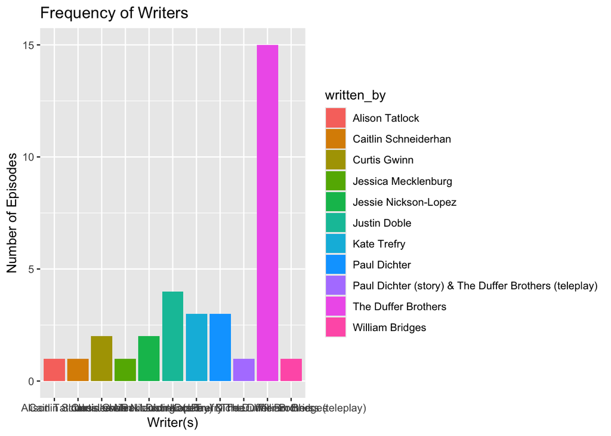

```r
df_episodes |>
  ggplot(aes(x = written_by, fill = written_by)) +
  geom_bar() +
   labs(x = "Writer(s)", y = "Number of Episodes", title = "Frequency of Writers")
```

As seen here, my hypothesis was correct. The Duffer Brothers have written 15 episodes on their own and 1 additional episode’s teleplay. This accounts for nearly half of all episodes of the show. The second most frequently seen writer is Justin Doble with only 4 episodes written. It is clear that the Duffer Brothers drive the story while other writers come in for only a few episodes at a time.

## Common Dialogue Words

I am interested in exploring the common words across all episodes of the show and episodes exclusively written by the Duffer Brothers, then comparing the two. I would expect to see a large overlap in the most common words, as they have the largest influence over the show’s writing. I will be excluding stop words in this analysis, but the name Will (a main character) becomes erased in doing so. I am not sure how to exclude this specific word from the anti_join. Also, the raw_text variable was repetitive to look at in the data set, so I removed it from the df_words data frame.

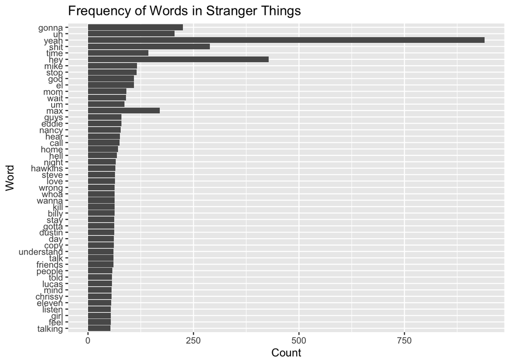

```r
df_dialogue <- df_dialogue |>
  left_join(df_episodes |> select(season, episode, title, written_by))
df_words <- df_dialogue |>
  subset(select = -c(raw_text)) |>
  unnest_tokens(word, dialogue) |>
  anti_join(stop_words)
df_writer_word_count <- df_words |>
  count(word, written_by) |>
  bind_tf_idf(word, written_by, n) |>
  drop_na()

df_writer_word_count |>
  group_by(word) |>
  filter(n > 50) |>
  arrange(desc(n)) |>
  ggplot(aes(x = n, y = reorder(word, n))) +
  geom_col(show.legend = FALSE) +
  labs(x = "Count", y = "Word", title = "Frequency of Words in Stranger Things")
```

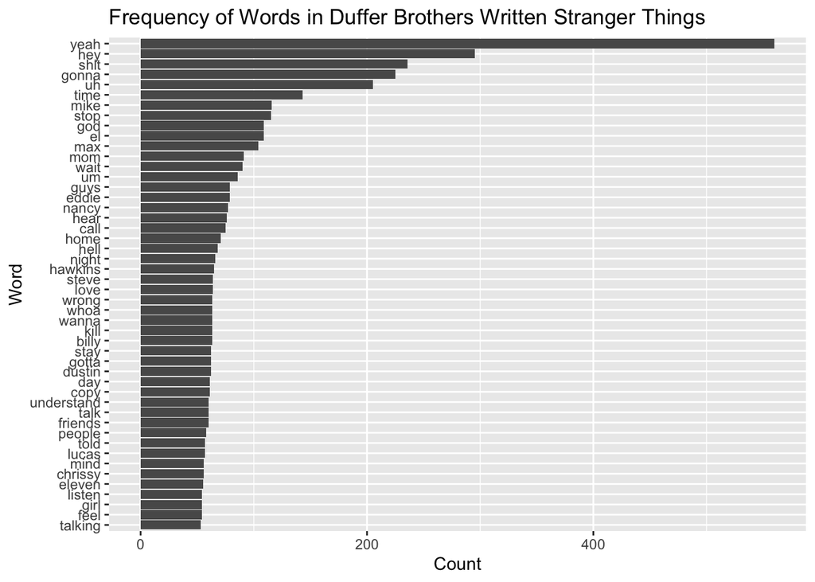

```r
df_writer_word_count |>
  group_by(word) |>
  filter(written_by == "The Duffer Brothers") |>
  filter(n > 50) |>
  arrange(desc(n)) |>
  ggplot(aes(x = n, y = reorder(word, n))) +
  geom_col(show.legend = FALSE) +
  labs(x = "Count", y = "Word", title = "Frequency of Words in Duffer Brothers Written Stranger Things")
```

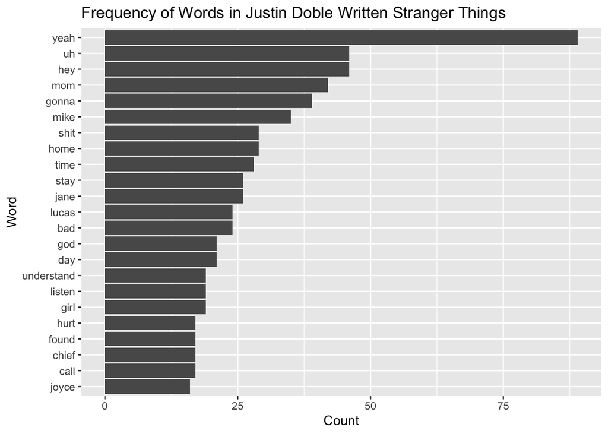

```r
df_writer_word_count |>
  group_by(word) |>
  filter(written_by == "Justin Doble") |>
  filter(n > 15) |>
  arrange(desc(n)) |>
  ggplot(aes(x = n, y = reorder(word, n))) +
  geom_col(show.legend = FALSE) +
  labs(x = "Count", y = "Word", title = "Frequency of Words in Justin Doble Written Stranger Things")
```

Overall, the frequency lists between all episodes and the Duffer Brothers’ episodes are almost identical in ratio and order. My hypothesis was correct. I also find it rather amusing that one of the most frequently used words in the show is “shit”. I remember the kids saying it a lot, but this is funny to see in the data with real numbers behind it. I decided to add in the analysis of Justin Doble’s writing as well to highlight the difference less episodes makes. Justin Doble’s episodes, however, consist of similar words but also many different ones. For example, “jane” is used in his episodes more than it is throughout the show. This is probably because his episodes relied on the story line of Jane’s character more so than the rest of the show did.

## Sentiment Analysis

I am curious to investigate the overall sentiment of the show through its dialogue and stage directions. I will be analyzing these separately.

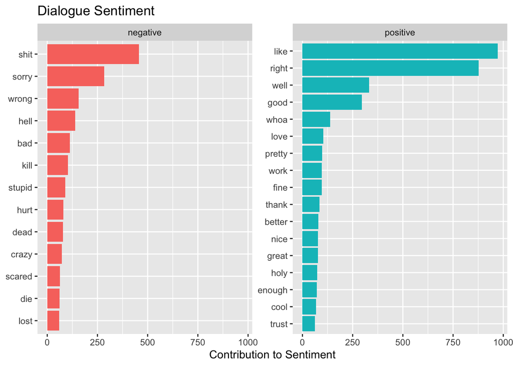

```r
dialogue_sent_counts <- df_dialogue |>
  unnest_tokens(word, dialogue) |>
  inner_join(get_sentiments("bing")) |>
  count(word, sentiment, sort = TRUE) |>
  ungroup() |>
  mutate(word = reorder(word, n))
stage_sent_counts <- df_dialogue |>
  unnest_tokens(word, stage_direction) |>
  inner_join(get_sentiments("bing")) |>
  count(word, sentiment, sort = TRUE) |>
  ungroup() |>
  mutate(word = reorder(word, n))
dialogue_sent_counts |>
  top_n(30, n) |>
  ggplot(aes(n, word, fill = sentiment)) +
  geom_col(show.legend = FALSE) +
  facet_wrap(~sentiment, scales = "free_y") +
  labs(x = "Contribution to Sentiment", y = NULL, title = "Dialogue Sentiment")
```

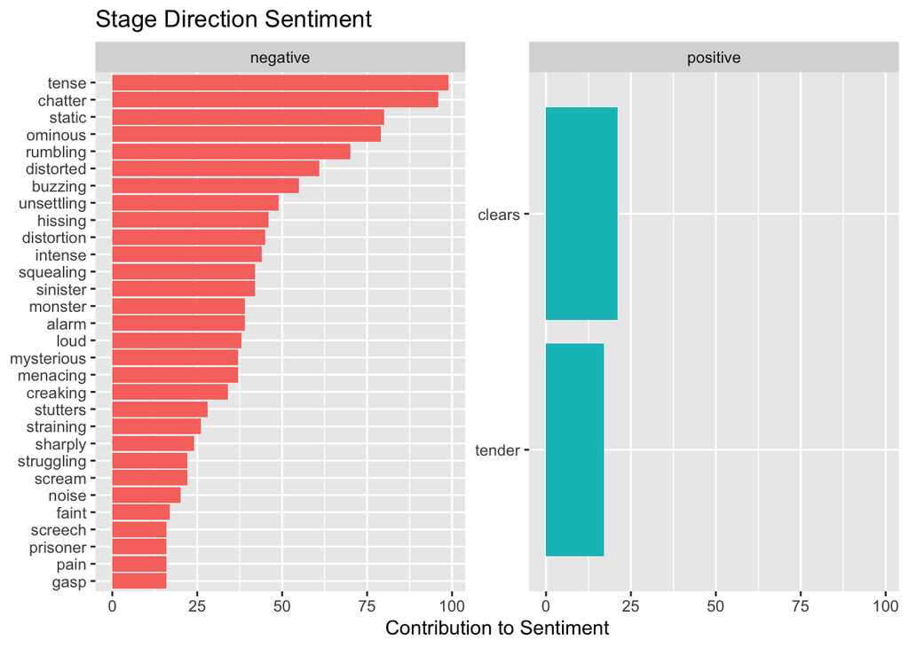

```r
stage_sent_counts |>
  top_n(30, n) |>
  ggplot(aes(n, word, fill = sentiment)) +
  geom_col(show.legend = FALSE) +
  facet_wrap(~sentiment, scales = "free_y") +
  labs(x = "Contribution to Sentiment", y = NULL, title = "Stage Direction Sentiment")
```

As shown in these sentiment analyses, the sentiment of the stage directions is far more negative than that of the dialogue. As someone who has seen the show, this makes a lot of sense. The show-runners want the audience to be unsettled and immersed in an eerie vibe for the show to have its intended effect. With the dialogue, however, the characters speak to each other and create a more balanced conversation sentiment dynamic.